# Roman Emperors

Zach

8/13/2019

## Setup

```r
library(tidyverse)
```

```r
emperors <- readr::read_csv("https://raw.githubusercontent.com/rfordatascience/tidytuesday/master/data/2019/2019-08-13/emperors.csv")
```

## Start

Ideas: - Plot a line graph of the birth and death dates of the emperors - Group by birth city - Look into rise variable - Look at breakdown of cause of death

## Explore

```r
glimpse(emperors)
```

```
## Observations: 68
## Variables: 16
## $ index       <int> 1, 2, 3, 4, 5, 6, 7, 8, 9, 10, 11, 12, 13, 14, 15,...
## $ name        <chr> "Augustus", "Tiberius", "Caligula", "Claudius", "N...
## $ name_full   <chr> "IMPERATOR CAESAR DIVI FILIVS AVGVSTVS", "TIBERIVS...
## $ birth       <date> 0062-09-23, 0041-11-16, 0012-08-31, 0009-08-01, 0...
## $ death       <date> 0014-08-19, 0037-03-16, 0041-01-24, 0054-10-13, 0...
## $ birth_cty   <chr> "Rome", "Rome", "Antitum", "Lugdunum", "Antitum", ...
## $ birth_prv   <chr> "Italia", "Italia", "Italia", "Gallia Lugdunensis"...
## $ rise        <chr> "Birthright", "Birthright", "Birthright", "Birthri...
## $ reign_start <date> 0026-01-16, 0014-09-18, 0037-03-18, 0041-01-25, 0...
## $ reign_end   <date> 0014-08-19, 0037-03-16, 0041-01-24, 0054-10-13, 0...
## $ cause       <chr> "Assassination", "Assassination", "Assassination",...
## $ killer      <chr> "Wife", "Other Emperor", "Senate", "Wife", "Senate...
## $ dynasty     <chr> "Julio-Claudian", "Julio-Claudian", "Julio-Claudia...
## $ era         <chr> "Principate", "Principate", "Principate", "Princip...
## $ notes       <chr> "birth, reign.start are BCE. Assign negative for c...
## $ verif_who   <chr> "Reddit user zonination", "Reddit user zonination"...
```

## Cause of death

```r
emperors %>%
  group_by(cause) %>%
  summarise(count = n()) %>%
  arrange(desc(count))
```

```
## # A tibble: 7 x 2
##   cause          count
##   <chr>          <int>
## 1 Assassination     25
## 2 Natural Causes    21
## 3 Execution          8
## 4 Died in Battle     5
## 5 Suicide            5
## 6 Unknown            3
## 7 Captivity          1
```

The majority of the emperors were either killed by assassination or natural causes.

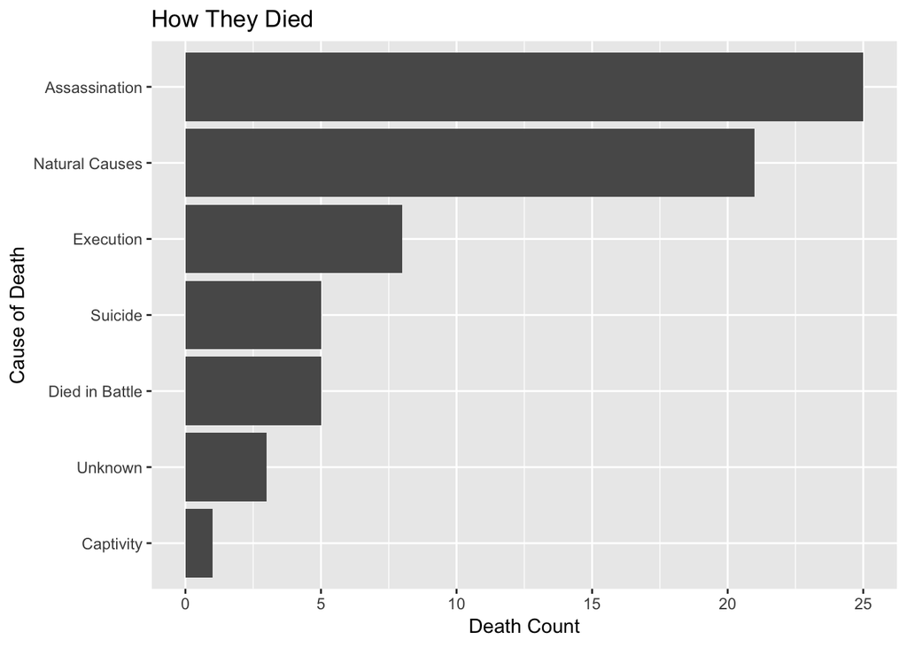

```r
emperors %>%
  group_by(cause) %>%
  summarise(count = n()) %>%
  arrange(desc(count)) %>%
  ggplot(aes(reorder(cause, count), count)) +
    geom_col() +
    labs(x="Cause of Death", y="Death Count", title="How They Died") +
    coord_flip()
```

## Lifespan

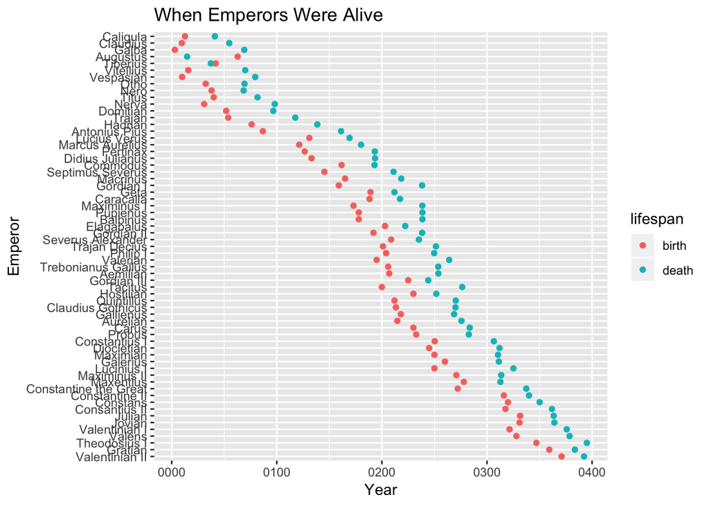

```r
emperors %>%
  filter(!is.na(birth), !is.na(death)) %>%
  gather(key = "lifespan", value = "date", birth, death, -name) %>%
  ggplot(aes(date, reorder(name, desc(date)), color = lifespan)) +
    geom_point() +
    labs(x="Year", y="Emperor", title="When Emperors Were Alive")
```

We can see when the emperors were alive. We also see that a couple of the emperors died before they were born! Guessing that is a typo and would look into swapping the values. Moving on.

Looking at the overlap of lifespans for the different emperors, there are many overlapping rulers. Let’s do the same thing, but looking at just their reign.

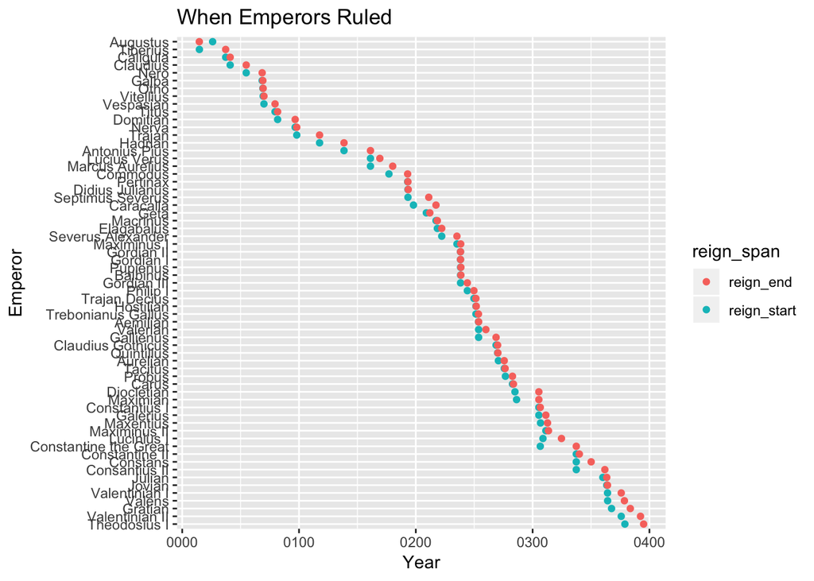

```r
emperors %>%
  filter(!is.na(birth), !is.na(death)) %>%
  gather(key = "reign_span", value = "date", reign_start, reign_end, -name) %>%
  ggplot(aes(date, reorder(name, desc(date)), color = reign_span)) +
    geom_point() +
    labs(x="Year", y="Emperor", title="When Emperors Ruled")
```

We see it is much tighter with much less overlap between rulers. Their reigns were quite much shorter. Look at some averages of the reigns and lifespans.

```r
emperors_life <- emperors %>%
  filter(!is.na(birth), !is.na(death)) %>%
  mutate(lifespan = death - birth,
         reign_span = reign_end - reign_start)

cat("Average Lifespan:", mean(emperors_life$lifespan))
```

```
## Average Lifespan: 17042.06
```

```r
cat("Average Reign:", mean(emperors_life$reign_span))
```

```
## Average Reign: 2966.651
```

The emperors were living, on average, to the ripe old age of 47, ruling around 8 years.

## Rise

```r
emperors %>%
  group_by(rise) %>%
  summarise("count"=n()) %>%
  arrange(desc(count))
```

```
## # A tibble: 8 x 2
##   rise                            count
##   <chr>                           <int>
## 1 Birthright                         35
## 2 Seized Power                       10
## 3 Appointment by Army                 7
## 4 Appointment by Senate               7
## 5 Appointment by Emperor              4
## 6 Appointment by Praetorian Guard     3
## 7 Election                            1
## 8 Purchase                            1
```

Looks like the most popular way to become emperor was to be born into it. Democratic Elections weren’t really in vogue at the time.

## Birth City

The cities look pretty specific, so let’s get a broad sense of where they are from with the `birth_prv` column.

```r
emperors %>%
  group_by(birth_prv) %>%
  summarise(count = n()) %>%
  arrange(desc(count))
```

```
## # A tibble: 18 x 2
##    birth_prv          count
##    <chr>              <int>
##  1 Italia                22
##  2 Pannonia              10
##  3 Unknown               10
##  4 Moesia                 4
##  5 Moesia Superior        3
##  6 Syria                  3
##  7 Gallia Lugdunensis     2
##  8 Gallia Narbonensis     2
##  9 Hispania Baetica       2
## 10 Thrace                 2
## 11 Africa                 1
## 12 Dacia Aureliana        1
## 13 Dalmatian              1
## 14 Hispania               1
## 15 Libya                  1
## 16 Mauretania             1
## 17 Pannonia Inferior      1
## 18 Phrygia                1
```

There are a bunch of unknowns, but a lot of the emperors in this dataset are from Italy and Pannonia, a province of the Roman Empire. So many of the Roman Emperors were born in Italy, but a bunch, of course, were also born within the Roman Empire itself.